# Bayesian Modeling Lab 06

8. Compare the output of our starting GLM model to our new GLMM model. How well do they compare?

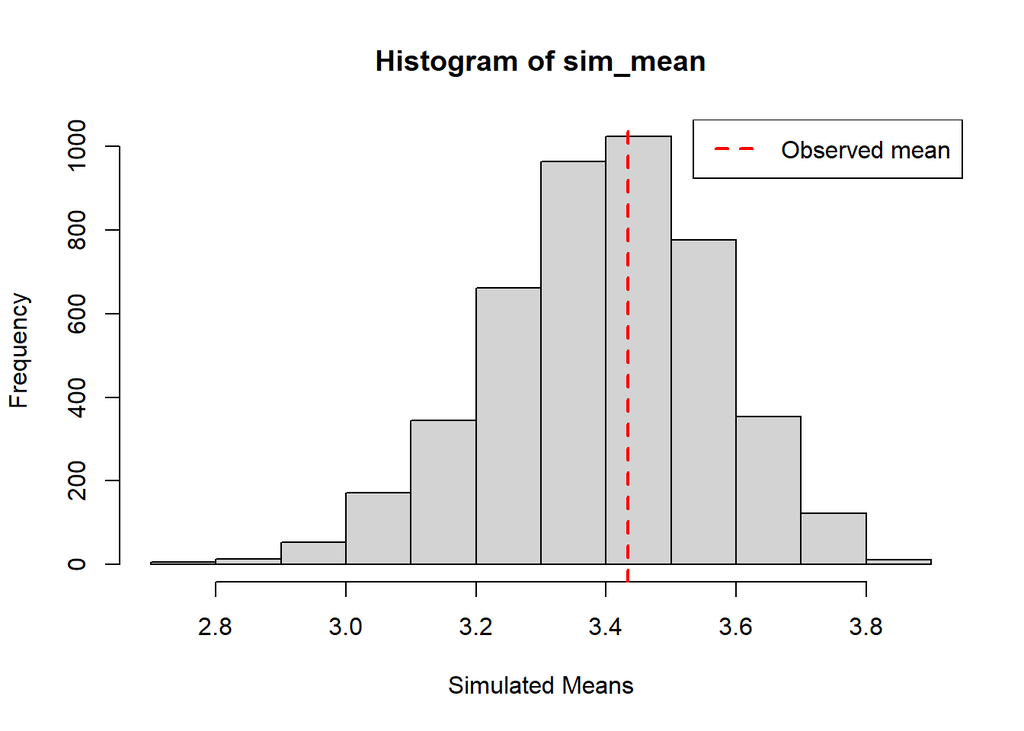

```r
ppd=MCMCchains(plants.fit1,params="y.new")
sim_mean=apply(ppd, 1, mean)
obs_mean=mean(plants$survs)

hist(sim_mean,breaks=10,xlab="Simulated Means",ylab="Frequency")
abline(v=mean(obs_mean),col="red",lwd=2,lty=2)
legend("topright",legend="Observed mean",col="red",lty=2,lwd=2)
```

```r
p_value=mean(sim_mean>obs_mean)
p_value
```

```
## [1] 0.4293333
```

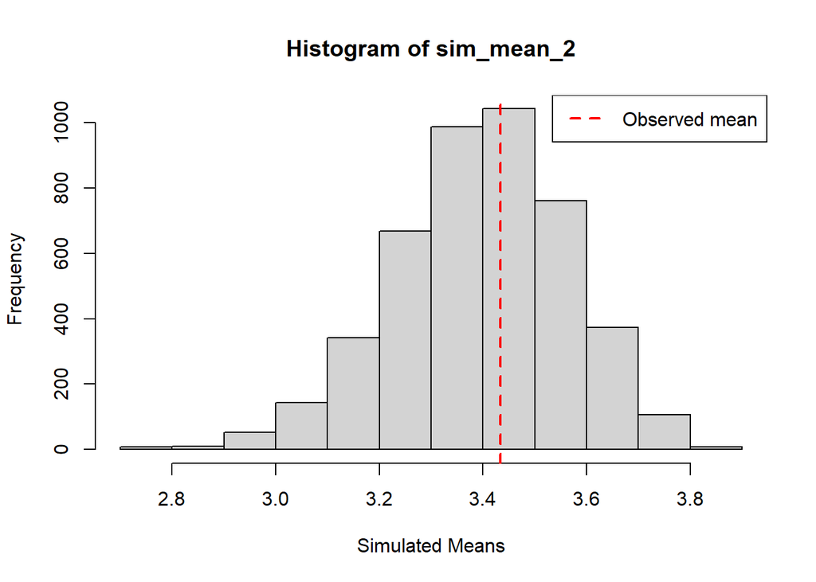

```r
ppd_2=MCMCchains(plants.fit2,params="y.new")
sim_mean_2=apply(ppd_2, 1, mean)
obs_mean=mean(plants$survs)

hist(sim_mean_2,breaks=10,xlab="Simulated Means",ylab="Frequency")
abline(v=mean(obs_mean),col="red",lwd=2,lty=2)
legend("topright",legend="Observed mean",col="red",lty=2,lwd=2)
```

```r
p_value_2=mean(sim_mean_2>obs_mean)
p_value_2
```

```
## [1] 0.432
```

```r
#Adding a random variable, the model does not actually improve significantly, thus we would not do that to increase the complexity of the mmodel
```

9. *BONUS:* We can visualize the variation from the random intercept by plotting the predicted response for the fixed effect of damage (both light and dark treatments) across all shadehouses. It looks something like this:

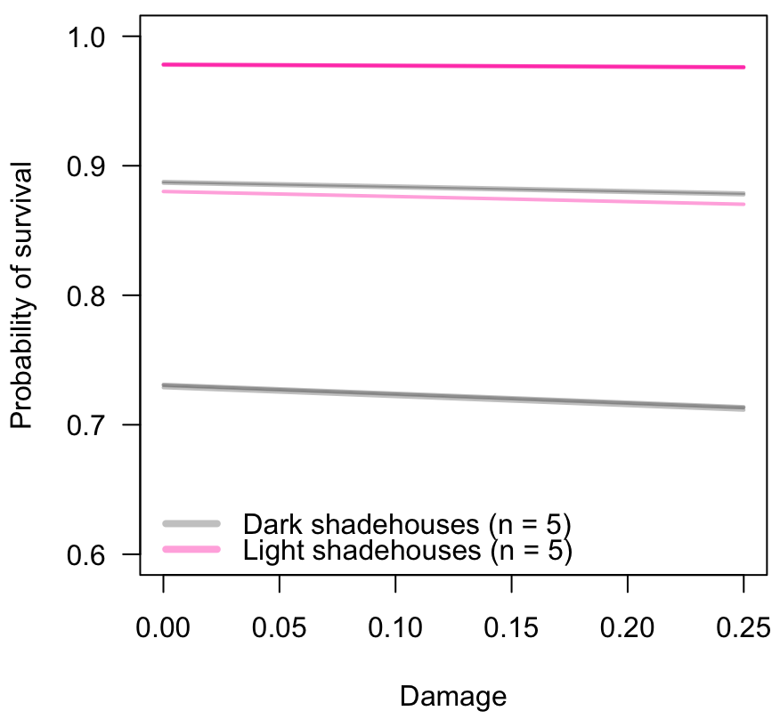

This isn’t accounting for uncertainty (e.g., uncertainty ribbons) and it doesn’t show the population-level effects, but it is useful in showing just how different the probability of survival is from shadehouse to shadehouse! This is mostly a plotting and coding challenge, not a statistical one, but if you have extra time, figuring out how to replicate this plot is worthwhile challenge.

## B. Caterpillars in forest fragments

As a reminder, our second dataset is from 10 forest fragments of varying size. The purpose of the study was to determine if the abundances of specialist and generalist caterpillars responded differently to fragment size. Each row is a species found in a fragment (species names are not given in the dataset).

| ForestName | SizeHa | Diet | Abundance |
| --- | --- | --- | --- |
| Choate KEC | 8.640 | Specialist | 2 |
| Choate KEC | 8.640 | Specialist | 2 |
| Choate KEC | 8.640 | Generalist | 9 |
| Choate KEC | 8.640 | Generalist | 10 |
| Choate KEC | 8.640 | Generalist | 4 |
| Cockaponset | 189.202 | Generalist | 7 |

Data in this table include: (a) Forest name; (b) Fragment size (in hectares); (c) whether each species observed was a specialist or generalist; and (d) abundance of each observed species.

1. We ended Lab 5 having run a Poisson model that fit poorly, concluding that the poor fit is likely due to overdispersion on the data. Let’s pick up where we left off, but improve upon Lab 5’s model, re-running it as a Negative Binomial GLM. But first, draw the DAG:
2. Now, define your data list[^2] and write your JAGS model. We haven’t run a ‘dnegbin()’ model in JAGS previously, so please note (the JAGS User Manual is helpful here!) that JAGS only uses the $NB(p,r)$ parameterization, whereas ecologists prefer the $NB(\lambda,\kappa)$ paramaterization. To adapt, we can still write our linear model as a log-linear function of an average ($\lambda$), but then we need an extra deterministic transformation in our model: $p_i=r/(r + \lambda_i)$. $r$ is our new overdispersion parameter and can be defined with a $Gamma(0.01,0.01)$ weak prior. With your JAGS code written, run the model with the same MCMC configuration as part A. How does it look?
3. In Lab 5, we evaluated this model with a posterior predictive check (which failed horribly!). Repeat that now, using the average abundnace as $T(y)$, and calculate the appropriate Bayesian p-value. If you didn’t create and monitor $y_{pred}$ in B.2, you’ll have to re-run your model.
4. Step B.4 should demonstrate that our new model fits *way* better due to the accounting for overdispersion. But now we have to face the problem of pseudoreplication. We’ve been treating each caterpillar species as independent, even though many are sampled in the same fragments. We don’t hypothesize that the fixed effects should change by fragment, so we only have to use a random intercept. But first, let’s draw the DAG:
5. Our data list will need `fragment` and `n.frags` to be added, and our JAGS code will need to add in the random intercept. Code both below, and run the model. Remember notes from B.2 and part A.[^3]
6. For our primary parameters of inference, how different is the interpretation from the GLM versus GLMM?
7. Just to be sure, let’s conduct a posterior predictive check for our model, as per step B.3, and make sure that our GLMM model continues to be an adequate fit for the data!
[^1]: at this point in the quarter, if you want to learn how to plot DAGS in R then you can use the ‘ggdag’ R package. First, build a DAG structure using `dagify()`, then plot using `ggdag()`, which uses the ggplot syntax.
[^2]: Remember to center and scale `size`
[^3]: You have have noticed by now that our models are running slower! As they become more complex and as we have more parameters, things will begin to slow.